# Introduction of geneHapR

Zhang RenLiang

2022-07-13

`geneHapR` is a package that designed for one or multi-genes haplotype analysis, visualization and phenotype association.

## Preliminaries

Input files frequently present challenges to analysis.

A common problem I encounter is that chromosome names and gene IDs are not standardized among **VCF**, **FASTA** and **GFF** files. That means additional work for users with or without R. I suggest that reading these files into R, synchronizing the names in R and then proceeding with downstream analyses.

Large **VCF** or **GFF** file is another important consideration when using geneHapR. Usually, the annotation file (GFF) and variants call format (VCF) files are commonly at chromosome or genome level. Thus they may be huge. However, a gene size is range from hundreds to thousands bp. It means the dataset for a gene haplotype analysis is very small portion inside the huge file. Thus I have developed `filterLargeVCF()` (see **VCF filtration**) in case the user known a little or nothing about linux. However, I suggest to extract the target ranges from the whole VCF or GFF file with in linux software before import them into R if the user is familiar with linux. It will save much time and brainwork if the user have hundred genes or ranges need to be extract from the original file.

## Installation

`geneHapR` could be installed from **gitee** (preferred) or **github**. More information about `geneHapR` could be found at https://gitee.com/zhangrenl/genehapr

```r
devtools::install_git("https://gitee.com/zhangrenl/geneHapR")
devtools::install_github("zhangrenl/geneHapR")
```

`geneHapR` is schemed to submit to CRAN. `geneHapR` has not published yet, if you use `geneHapR` in your study, please contact Zhang RenLiang (email: zhang_renliang@163.com) or Jia GuanQing (jiaguanqing@caas.cn)

## Data input

The first step is library the `geneHapR` packages.

```r
library(geneHapR)
```

There are two options to conduct a gene haplotype analysis starts from a VCF file or DNA sequcences file. Thus a **VCF** file or **DNA sequences** file is necessary. However, the *GFF*, *phenos* and *accession groups* are strongly recommend for visualization and phenotype associations.

The import functions takes file name/path as input. `import_vcf()` could import VCF file with surfix of “.vcf” and “.vcf.gz”. `import_gff()` import file format default as “GFF” and `import_seqs()` file format default as “fasta”.

### Import VCF

```r
# import vcf file
vcf <- import_vcf("your_vcf_file_path.vcf")

# import gziped vcf file
vcf <- import_vcf("your_vcf_file_path.vcf.gz")
```

### Import GFF

```r
# import GFFs
gff <- import_gff("your_gff_file_path.gff", format = "GFF")
```

### Import DNA sequences

```r
# import DNA sequences in fasta format
seqs <- import_seqs("your_DNA_seq_file_path.fa", format = "fasta")
```

## Import phenotype and accession group information

```r
# import phynotype data
pheno <- import_pheno("your_pheno_file_path.txt")
pheno
```

```
##    GrainWeight.2021 GrainWeight.2022
## C1            16.76            18.76
## C2             6.66             8.66
## C3             7.80            16.30
## C4            19.73            23.73
## C5            11.95            16.95
## C6            12.43            30.45
```

```r
# import accession group information
accGroup <- import_pheno("accession_group_file_path.txt")
```

```
##     Sensitive             Type  Hap
## C1  Sensitive Mordern cultivar H007
## C2 Resistance Mordern cultivar H008
## C3        Mid Mordern cultivar H009
## C4  Sensitive Mordern cultivar H005
## C5 Resistance Mordern cultivar H002
## C6        Mid Mordern cultivar H003
```

Be aware that the phenotype and accession group are effectively tables. There are more than one ways to import a table format file with `R`.

Just **Note** that: a. the accession/individual names located in first column; b. the first row contents phenotype/accession_group names; c. `NA` is allowed, it’s not a wise option to replace `NA` by `0`.

eg.

```r
# import pheno from space ' ' delimed table
pheno <- read.table("your_pheno_file_path.csv", header = TRUE, row.names = 1, comment.char = "#")

# import pheno from ',' delimed table
pheno <- read.csv("your_pheno_file_path.csv", header = TRUE, comment.char = "#")
```

## Data manipulations

There is a little work need to be done before haplotype calculations: (1) VCF filtration and (2) DNA sequences alignment.

### VCF filtration

There are three modes to filter a `vcfR` object after import VCF into R: a. by position; b. by annotation; c. by both of them.

```r
# filter VCF by position
vcf_f1 <- filter_vcf(vcf, mode = "POS",
                     Chr = "scaffold_1",
                     start = 4300, end = 5890)

# filter VCF by annotation
vcf_f2 <- filter_vcf(vcf, mode = "type",
                     gff = gff,
                     type = "CDS")

# filter VCF by position and annotation
vcf_f3 <- filter_vcf(vcf, mode = "both",
                     Chr = "scaffold_1",
                     start = 4300, end = 5890,
                     gff = gff,
                     type = "CDS")
```

It’s a time consuming work to import and manipulate a very large file with R on personal computer. It’ll be more efficiency to extract the target ranges from origin VCF with `filterLargeVCF()` before import. If your VCF file is just a few ‘MB’, this step was not necessary at all.

**Note:** if extract more than one ranges, length of output file names (`VCFout`) must be equal with `Chr` and `POS`.

```r
# new VCF file will be saved to disk
# extract a single gene/range from a large vcf
filterLargeVCF(VCFin = "Ori.vcf.gz",
               VCFout = "filtered.vcf.gz",
               Chr = "scaffold_8",
               POS = c(19802,24501),
               override = TRUE)

# extract multi genes/ranges from large vcf
filterLargeVCF(VCFin = "Ori.vcf.gz",          # surfix should be .vcf.gz or .vcf
               VCFout = c("filtered1.vcf.gz", # surfix should be .vcf.gz or .vcf
                          "filtered2.vcf.gz",
                          "filtered3.vcf.gz"),
               Chr = c("scaffold_8",
                       "scaffold_8",
                       "scaffold_7"),
               POS = list(c(19802,24501),
                          c(27341,28949),
                          c(38469,40344)),
               override = TRUE)               # if TRUE, existed file will be override without warning
```

### DNA sequences manipulation

The origin DNA sequences must be aligned and trimmed due to haplotype calculation need all sequences have same length. Those operations could be done with `geneHapR`. I still suggest users align and trim DNA sequences with **Mega** software and then save the result as *FASTA* format before import them into R.

```r
# sequences alignment
seqs <- allignSeqs(seqs, quiet = TRUE)

# sequences trim
seqs <- trimSeqs(seqs, minFlankFraction = 0.1)
seqs
```

## Haplotype calculation

As mentioned before, haplotype could be calculated from VCF or sequences with `vcf2hap()` or `seqs2hap()`. The genotype of most sites should be known and homozygous, still, a few site are unknown or heterozygous due to chromosome variant or error cased by sequencing or SNP calling or gaps or other reasons. It’s a hard decision whether to drop accessions/individuals contains heterozygous or unknown sites for every haplotype analysis. Hence, I leave the choice to users.

Calculate haplotype result from VCF.

```r
hapResult <- vcf2hap(vcf,
                     hapPrefix = "H",
                     hyb_remove = TRUE,
                     na.drop = TRUE)
hapResult
```

```
## Accessions:
##  All:      37
##  Removed: 4  C12, C16, C29, C33
##  Remain:  33
##
## hap frequences:
## H001 H002 H003 H004 H005 H006 H007 H008 H009
##   10    8    4    4    2    2    1    1    1
##
## Options:
##  hapPrefix:  H
##  CHROM:      scaffold_1
##  POS:        4300-6856
##  hyb_remove: YES
##  NA_remove:  YES
##
## # A tibble: 37 × 11
##    Hap    `4300`     `4345`     `4879` `4910` `4950` `5037` `5209` `5213` `6856`
##    <chr>  <chr>      <chr>      <chr>  <chr>  <chr>  <chr>  <chr>  <chr>  <chr>
##  1 CHR    scaffold_1 scaffold_1 scaff… scaff… scaff… scaff… scaff… scaff… scaff…
##  2 POS    4300       4345       4879   4910   4950   5037   5209   5213   6856
##  3 INFO   <NA>       <NA>       <NA>   <NA>   <NA>   <NA>   <NA>   <NA>   <NA>
##  4 ALLELE G/C        T/A,GG     T/A,G  GCCTA… T/AA,… A/AA,… A/AC   C/G    A/G
##  5 H001   G          T          T      GCCTA  T      A      A      C      A
##  6 H001   G          T          T      GCCTA  T      A      A      C      A
##  7 H001   G          T          T      GCCTA  T      A      A      C      A
##  8 H001   G          T          T      GCCTA  T      A      A      C      A
##  9 H001   G          T          T      GCCTA  T      A      A      C      A
## 10 H001   G          T          T      GCCTA  T      A      A      C      A
## # … with 27 more rows, and 1 more variable: Accession <chr>
```

Calculate haplotype result from aligned DNA sequences.

```r
hapResult <- seqs2hap(seqs,
                      Ref = names(seqs)[1],
                      hapPrefix = "H",
                      hyb_remove = TRUE,
                      na.drop = TRUE,
                      maxGapsPerSeq = 0.25)
```

## Adjustment of `hapResult`

Before visualization, there were a few details need to be adjusted. eg. add annotations and adjust position of “ATG”

### Add annotations to `hapResult`

While `hapResult` was calculated from `vcfR` object, the **INFO** was taken from `@fix` field. The *VCF INFO* may missing some annotations. or contents format was inappropriate to display. Further more, **INFO** contents nothing if `hapResult` was generated from sequences. Here, we can introduce/replace the origin **INFO** by `addINFO()`.

**Note** that: length of `values` must be equal with number of sites.

Let’s see how mant sites contains in the `hapResult`.

```r
# Chech number of sites conclude in hapResult
sites(hapResult)
```

```
## [1] 9
```

Now we replace the old INFO field with new tag named as “PrChange”.

```r
# add annotations to INFO field
hapResult <-addINFO(hapResult,
                     tag = "PrChange",
                     values = rep(c("C->D", "V->R", "G->N"),3),
                     replace = TRUE)
```

Here, we add a tag named as “CDSChange” followed the old INFO.

```r
# To replace the origin INFO by set 'replace' as TRUE
hapResult <-addINFO(hapResult,
                     tag = "CDSChange",
                     values = rep(c("C->A", "T->C", "G->T"),3),
                     replace = FALSE)
```

### Adjust position of “ATG”

This function was only used to adjust the position of “ATG” to 0 and hence convert the gene on negative strand to positive strand.

Be note that: **GFF** and **hapResult** need to adjust position of *ATG* with the same parameters.

```r
# set ATG position as zero in gff
newgff <- gffSetATGas0(gff = gff, hap = hapResult,
                       geneID = "test1G0387",
                       Chr = "scaffold_1",
                       POS = c(4300, 7910))

# set position of ATG as zero in hapResult/hapSummary
newhap <- hapSetATGas0(gff = gff, hap = hapResult,
                       geneID = "test1G0387",
                       Chr = "scaffold_1",
                       POS = c(4300, 7910))
```

## `hapResult` summary and visualization

Once we have the `hapResult` object, can we summarize and visualize our `hapResult` by interact with annotations and phenotypes.

### Summary hapResult

Now, we have the `hapResult` object with INFOs we want display in next step. The `hap_summary()` function convert the object of `hapResult` class, which is a long table format, into a short table belong to `hapSummary` class. In `hapResult` each row represent a accession, while each row represents a hap in `hapSummary`.

```r
hapSummary <- hap_summary(hapResult)
hapSummary
```

```
##
## Accssions: 33
## Sites: 9
##   Indels: 5
##   SNPs:   4
##
## Haplotypes: 9
##   H001   10  C8, C9, C11, C14, C18, C25, ...
##   H002   8   C5, C15, C17, C19, C22, C32, ...
##   H003   4   C6, C20, C23, C37
##   H004   4   C7, C13, C24, C30
##   H005   2   C4, C21
##   H006   2   C10, C27
##   H007   1   C1
##   H008   1   C2
##   H009   1   C3
##
## Options:
##  hapPrefix:  H
##  CHROM:  scaffold_1
##  POS:    4300-6856
##  hyb_remove: YES
##  NA_remove:  YES
##
## # A tibble: 13 × 12
##    Hap    `4300`         `4345` `4879` `4910` `4950` `5037` `5209` `5213` `6856`
##    <chr>  <chr>          <chr>  <chr>  <chr>  <chr>  <chr>  <chr>  <chr>  <chr>
##  1 CHR    scaffold_1     scaff… scaff… scaff… scaff… scaff… scaff… scaff… scaff…
##  2 POS    4300           4345   4879   4910   4950   5037   5209   5213   6856
##  3 INFO   PrChange=C->D… PrCha… PrCha… PrCha… PrCha… PrCha… PrCha… PrCha… PrCha…
##  4 ALLELE G/C            T/A,GG T/A,G  GCCTA… T/AA,… A/AA,… A/AC   C/G    A/G
##  5 H001   G              T      T      GCCTA  T      A      A      C      A
##  6 H002   C              T      T      A      T      A      A      G      A
##  7 H003   G              A      A      A      AA     AA     AC     G      A
##  8 H004   G              T      T      A      T      A      A      G      A
##  9 H005   G              T      G      GCCTA  T      GGG    A      C      A
## 10 H006   G              T      T      A      T      A      A      G      G
## 11 H007   C              GG     G      A      GG     CC     A      G      A
## 12 H008   G              GG     T      A      T      CC     A      G      G
## 13 H009   G              T      T      A      GG     GGG    A      G      G
## # … with 2 more variables: Accession <chr>, freq <int>
```

### Visualize haplotye as table

Let’s see how to visualization of our haplotype results.

At first let’s display the `hapSummary` as a table. In this table like figure we can see all the variants and their positions, haplotypes and their frequencies.

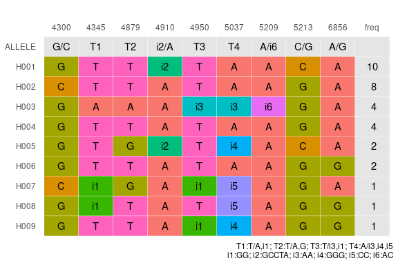

```r
plotHapTable(hapSummary)
```

Also we can add an annotation, “CDSChange”, to the table by assign the `INFO_tag`. It’s your responsibility to verify whether the INFO_tag was existed in the INFO field.

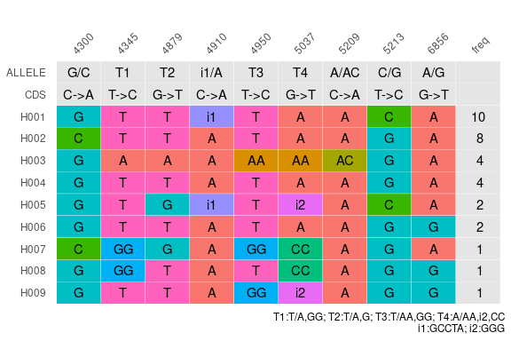

```r
# add one annotation
plotHapTable(hapSummary,
             hapPrefix = "H",
             INFO_tag = "CDSChange",
             tag_name = "CDS",
             displayIndelSize = 1,
             angle = 45,
             replaceMultiAllele = TRUE,
             ALLELE.color = "grey90")
```

Now let’s add another `INFO_tag` named as “PrChange”.

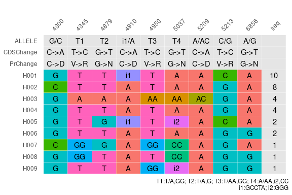

```r
# add multi annotation
plotHapTable(hapSummary,
             hapPrefix = "H",
             INFO_tag = c("CDSChange", "PrChange"),
             displayIndelSize = 1,
             angle = 45,
             replaceMultiAllele = TRUE,
             ALLELE.color = "grey90")
```

Parameter `tag_name` was used to replace the character if `INFO_tag` was too long.

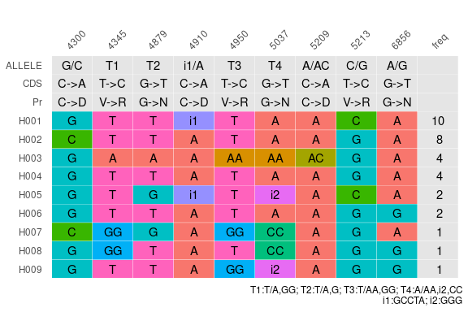

```r
# add multi annotation
plotHapTable(hapSummary,
             hapPrefix = "H",
             INFO_tag = c("CDSChange", "PrChange"),
             tag_name = c("CDS", "Pr"),
             displayIndelSize = 1,
             angle = 45,
             replaceMultiAllele = TRUE,
             ALLELE.color = "grey90")
```

### Display variations on gene model.

I think it’s a good idea to figure out where are the variants by marking them on gene model.

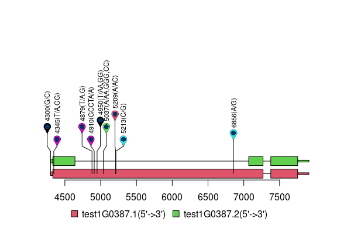

```r
displayVarOnGeneModel(gff,
                      hapSummary,
                      Chr = "scaffold_1",
                      startPOS = 4300, endPOS = 7910,
                      type = "pin", cex = 0.7,
                      CDS_h = 0.05, fiveUTR_h = 0.02, threeUTR_h = 0.01)
```

### `hapNet` calculation and visualization

The `hapNet` could be generated from object of `hapSummary` class. The accession group information could be attached in this step.

```r
hapNet <- get_hapNet(hapSummary,
                     accGroup = accGroup,
                     groupName = "Type")
```

Once we have the `hapNet` object, we can plot it with R.

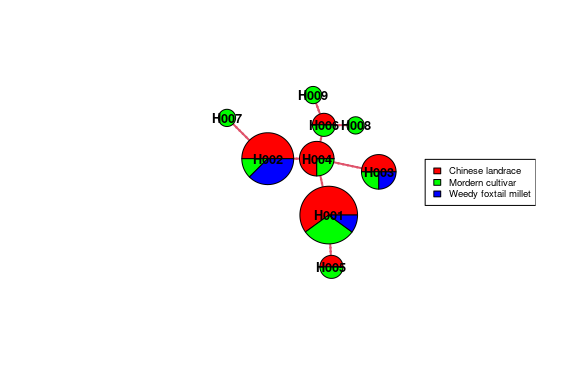

```r
# plot haploNet
plotHapNet(hapNet,
           size = "freq", scale.ratio = 1,  # circle size
           scale = TRUE,                    # scale circle with 'log10(size + 1)'
           cex = 0.8,                       # size of hap symbol
           col.link = 2,                    # link colors
           link.width = 2,                  # link widths
           show.mutation = 2,               # mutation types one of c(0,1,2,3)
           legendPosition = "right")        # legend position
```

### Phenotype association analysis

Finally, let’s see which haplotype has superiority at particular area by interact with phynotype.

Here are two options, merged or separated, to organized the heatmap of p-values and violin plot. The figure as an object of `ggplot2`, which means user could add/modified figure elements with `ggplot2`.

Here is an example for merged arrangement:

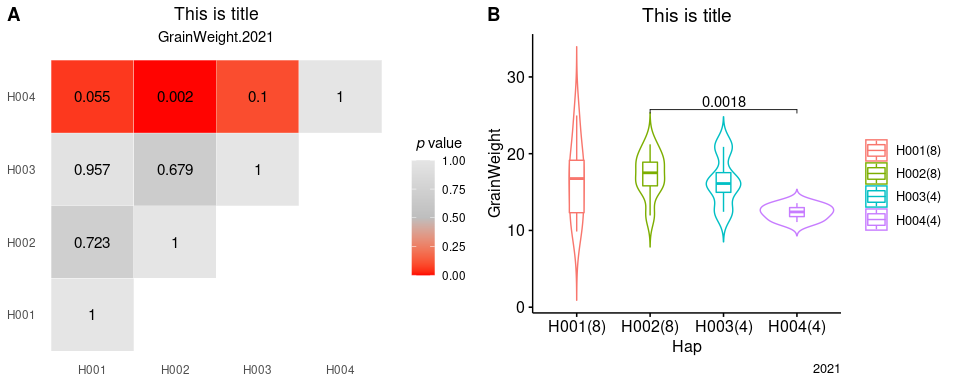

```r
results <-hapVsPheno(hapResult,
                     hapPrefix = "H",
                     title = "This is title",
                     mergeFigs = TRUE,
                     pheno = pheno,
                     phenoName = "GrainWeight.2021",
                     minAcc = 3)
plot(results$figs)
```

**An example for separated plot:**

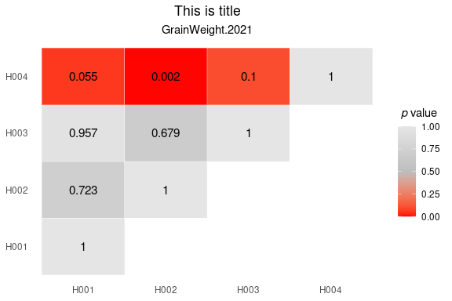

```r
results <- hapVsPheno(hap = hapResult,
                      hapPrefix = "H",
                      title = "This is title",
                      pheno = pheno,
                      phenoName = "GrainWeight.2021",
                      minAcc = 3,
                      mergeFigs = FALSE)
plot(results$fig_pvalue)
```

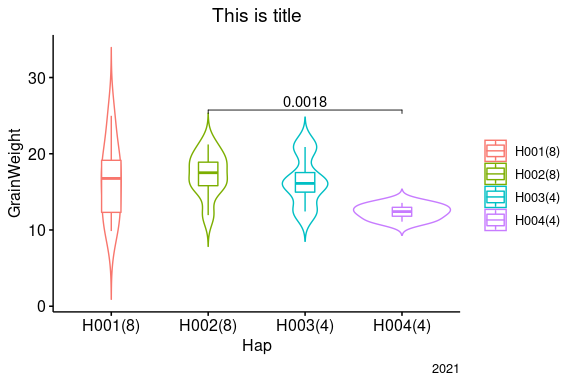

```r
plot(results$fig_Violin)
```

### Association analysis of multi-phenotypes once a time

I believe the function of `hapVsPhenos()` will be useful when you have a lot of phenotype need to be associated with haplotype results.

Note that: the pheno name will be added between the file name and surfix.

```r
hapVsPhenos(hapResult,
            pheno,
            outPutSingleFile = TRUE,
            hapPrefix = "H",
            title = "Seita.0G000000",
            file = "mypheno.tiff",
            width = 12,
            height = 8,
            res = 300)
```